+++ title = "Analyzing Stocks in R" date = 2020-10-05 +++

# Stuart’s Portfolio

Henry Overos

9/27/2020

# Checking the Portfolio:

## Setting up `R`

First, I set up R by loading the `tidyverse` and `tidyquant` packages. These packages allow for easier coding and downloading of financial data from **Yahoo Finance**.

```r
pacman::p_load(tidyverse,tidyquant,quantmod,forecast,tseries,timeSeries,prophet,fGarch)
```

I’m going to start by demonstrating a simple analysis of the **Vanguard S&P 500 ETF** (VOO). VOO is a simple ETF that buys equal fractions of the S&P 500 stocks available. It basically mirrors the market itself. This is a useful baseline to compare the returns on a more advanced portfolio.

First, I download the stock data from the past decade for VOO.

```r
VOO <- "VOO" %>% tq_get(get = "stock.prices",
                        from = "2010-01-01",
                        to = "2020-09-21")
knitr::kable(head(VOO))
```

| symbol | date | open | high | low | close | volume | adjusted |
| --- | --- | --- | --- | --- | --- | --- | --- |
| VOO | 2010-09-09 | 102.50 | 102.50 | 101.14 | 101.32 | 26500 | 82.36287 |
| VOO | 2010-09-10 | 101.68 | 101.86 | 101.30 | 101.78 | 8600 | 82.73678 |
| VOO | 2010-09-13 | 102.96 | 103.14 | 102.50 | 103.06 | 33700 | 83.77728 |
| VOO | 2010-09-14 | 102.84 | 103.48 | 102.38 | 103.04 | 59400 | 83.76104 |
| VOO | 2010-09-15 | 102.62 | 103.38 | 102.40 | 103.30 | 9200 | 83.97239 |
| VOO | 2010-09-16 | 103.02 | 103.32 | 102.70 | 103.26 | 59500 | 83.93987 |

As you can see, the dataset available provides that day’s high, low, open and closing prices. It also shows the adjusted price which we will use for our intiial analysis.

I also use the `periodReturn` function, which takes the adjusted closing price and calculates the return for each day in the dataset.

```r
VOO_return <- VOO %>% tq_transmute(select = adjusted,
               mutate_fun = periodReturn,
               period = "daily",
               col_rename = "return")
```

Because I wasn’t sure if their code was the same as how I would measure returns, I compared returns based on the simple formula below to the `periodReturn` function and the results are the same.

```r
n <- nrow(VOO)

VOO_return$hand[1] <- 0

VOO_return$hand[2:n] <- ((VOO$close[2:n] - VOO$close[1:(n-1)])/VOO$close[1:(n-1)])

knitr::kable(head(VOO_return))
```

| date | return | hand |
| --- | --- | --- |
| 2010-09-09 | 0.0000000 | 0.0000000 |
| 2010-09-10 | 0.0045398 | 0.0045401 |
| 2010-09-13 | 0.0125760 | 0.0125761 |
| 2010-09-14 | -0.0001938 | -0.0001940 |
| 2010-09-15 | 0.0025232 | 0.0025233 |
| 2010-09-16 | -0.0003872 | -0.0003872 |

Lets now visualize the prices of the stock and get an idea of how much you’d make with a small investment a decade ago.

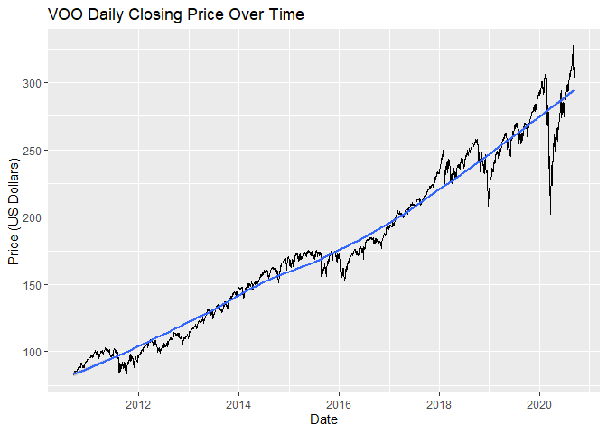

Figure 1 presents the daily adjusted closing price from the data. The black line is the actual closing price, while the blue is the smoothed average of the price over time.

```r
VOO %>%
  ggplot(aes(x = date, y = adjusted)) +
  geom_line() +
  geom_smooth(method = "loess") +
  labs(title = "VOO Daily Closing Price Over Time") +
  xlab("Date") +
  ylab("Price (US Dollars)")
```

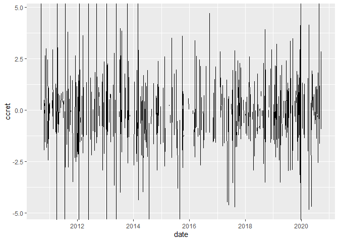

```r
n <- nrow(VOO_return)
VOO_return$ccret <- NULL
VOO_return$ccret[1] <- 0
VOO_return$ccret[2:n] <- log(VOO_return$return[2:n]) - log(VOO_return$return[1:(n-1)])

VOO_return %>%
  ggplot(aes(x = date, y = ccret)) +
  geom_line()
```

This next plot is pretty obvious, considering the price of the stock, but lets say we invested $1 into it a decade ago. The value of that dollar today would be about $3.50. That’s a pretty great investment! It’s definitely slower than other stocks but consider that this is essentially the least risky stock in which you could invest.

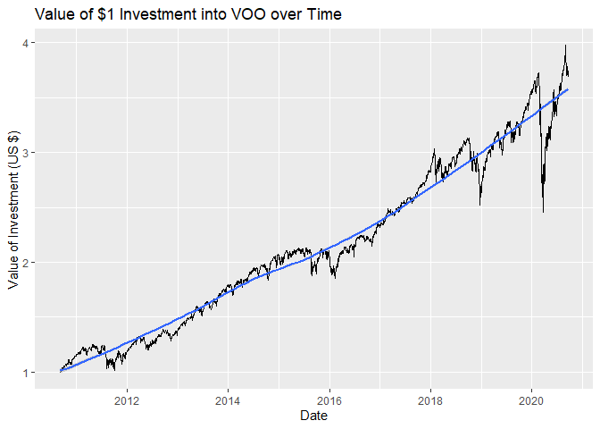

```r
VOO_return$gret <- 1 + VOO_return$return

VOO_return$fv <- cumprod(VOO_return$gret)

VOO_return %>%
  ggplot(aes(x = date, y = fv)) +
  geom_line() +
  geom_smooth(method = "loess") +
  labs(title = "Value of $1 Investment into VOO over Time") +
  xlab("Date") +
  ylab("Value of Investment (US $)")
```

Lets say we wanted to have a regular investment at monthly intervals. So, we put $1 into the VOO stock every month for the past decade. Lets visualize what that would look like.

```r
VOO_return_m <- VOO %>% tq_transmute(select = adjusted,
               mutate_fun = periodReturn,
               period = "monthly",
               col_rename = "return")

VOO_return_m$total_input <- 1:121

VOO_return_m$gret <- 1 + mean(VOO_return_m$return)
mean(VOO_return_m$return)
```

```
## [1] 0.01156886
```

```r
future_value_annuity <- function(pv,pmt,r,k,n){
  pv*(1+(r/k))^(n*k)+pmt*(((1+(r/k))^(n*k)-1)/(r/k))
  }

future_value_annuity(pv=1,pmt=1,n=10,r=0.011,k=12)
```

```
## [1] 127.9037
```

Lets say we invested $100 a month, a total of $12000 over the course of the decade.

```r
100*12*10
```

```
## [1] 12000
```

```r
future_value_annuity(pv=100,pmt=100,n=10,r=0.011,k=12)
```

```
## [1] 12790.37
```

For the sake of comparison, lets make a portfolio that invests in multiple, popular stocks as well as VOO. I picked Apple, Microsoft, Netflix and Facebook as well as Vanguard.

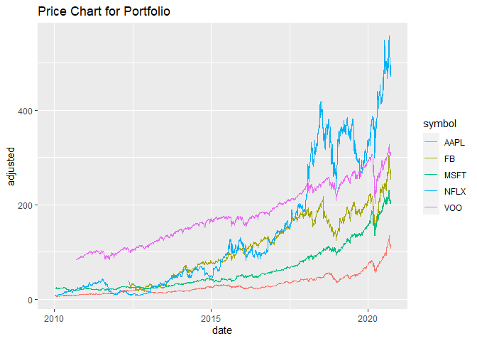

```r
tickers <- c("VOO", "AAPL", "MSFT", "NFLX", "FB")

mult_stocks <- tickers %>%
  tq_get(get = "stock.prices",
         from = "2010-01-01",
         to = "2020-09-21")

mult_stocks %>%
  ggplot(aes(x = date, y = adjusted, color = symbol)) +
  geom_line() +
  ggtitle("Price Chart for Portfolio")
```

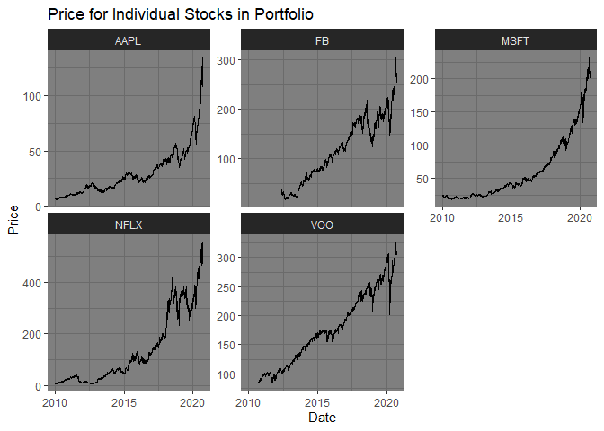

```r
mult_stocks %>%
  ggplot(aes(x = date, y = adjusted)) +
  geom_line() +
  facet_wrap(~symbol, scales = "free_y") +
  theme_dark() +
  labs(x = "Date", y = "Price")+
  ggtitle("Price for Individual Stocks in Portfolio")
```

As you can see in this comparison chart and the individual graphs for each stock, VOO is a more stable investment that does steadily rise. It has fewer dips and they’re not drastic at all, except in the case of a major recession like what occurred in March 2020. These other stocks started out the decade worth a lot less than VOO at its start but their growth has been exponential (literally, in the case of NFLX).

Lets see the returns on this portfolio.

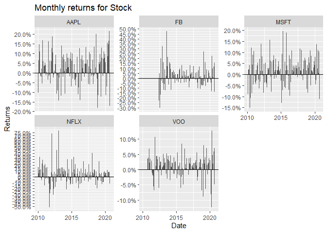

```r
mult_returns <- mult_stocks %>%
  group_by(symbol) %>%
  tq_transmute(select = adjusted,
               mutate_fun = periodReturn,
               period = "monthly",
               col_rename = "return")

mult_returns %>%
  ggplot(aes(x = date, y = return)) +
  geom_bar(stat = "identity") +
  geom_hline(yintercept = 0) +
  facet_wrap(~symbol, scales = "free_y") +
  scale_y_continuous(labels = scales::percent,
                     breaks = seq(-0.5,0.75,0.05)) +
  ggtitle("Monthly returns for Stock") +
  labs(x = "Date", y = "Returns") +
  scale_fill_brewer(palette = "Set1",   # We will give them different colors instead of black
                     name = "",
                     guide = FALSE)
```

You can see from the above graphs that VOO is relatively consistent in its returns followed by Microsoft and Apple. Facebook presents larger returns in general, usually between 10-20 percent but sometimes spiking to 50. Netflix is the best in terms of what it provides, some months almost providing a return of 80 percent.

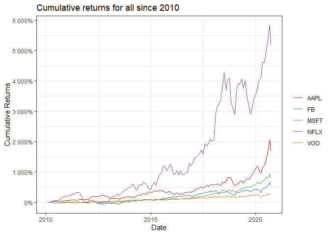

```r
mult_returns %>%
  mutate(return = if_else(date == "2010-01-29", 0, return)) %>%
  group_by(symbol) %>%  # Need to group multiple stocks
  mutate(cr = cumprod(1 + return)) %>%
  mutate(cumulative_returns = cr - 1) %>%
  ggplot(aes(x = date, y = cumulative_returns, color = symbol)) +
  geom_line() +
  labs(x = "Date", y = "Cumulative Returns") +
  ggtitle("Cumulative returns for all since 2010") +
  scale_y_continuous(breaks = seq(0,70,10),
                     labels = scales::percent) +
  scale_color_brewer(palette = "Set1",
                     name = "") +
  theme_bw()
```

The cumulative returns tell the same story but the visuals present the stark contrast between the companies. Netflix is by far the best investment with a cumulative return nearing 6000 percent of the intial investment of $1 a decade ago. Second, is Apple. But its a far second. Let me demonstrate the same graph sans Netflix to provide a sense of scale between the smaller returns.

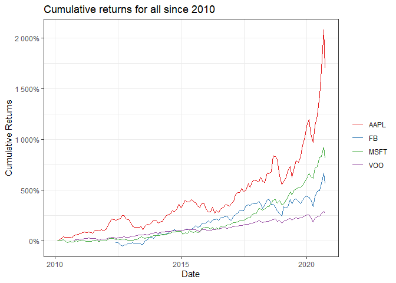

```r
mult_returns %>%
  dplyr::filter(symbol != "NFLX") %>%
  mutate(return = if_else(date == "2010-01-29", 0, return)) %>%
  group_by(symbol) %>%  # Need to group multiple stocks
  mutate(cr = cumprod(1 + return)) %>%
  mutate(cumulative_returns = cr - 1) %>%
  ggplot(aes(x = date, y = cumulative_returns, color = symbol)) +
  geom_line() +
  labs(x = "Date", y = "Cumulative Returns") +
  ggtitle("Cumulative returns for all since 2010") +
  scale_y_continuous(breaks = seq(0,20,5),
                     labels = scales::percent) +
  scale_color_brewer(palette = "Set1",
                     name = "") +
  theme_bw()
```

So, you can see here that Apple is still a great investment when comparing these other major companies. VOO is not a sexy stock. It follows a much more linear trend than the other stocks, this is because VOO is actually just a representation of the trend of the market as a whole. Thus, we can conclude that regardless of your investment strategy, the value of any investment is definitely moving up in the longterm. But to capitalize on the fluctuation of the market, a good strategy would involve investments into separate stocks that carry some level of risk. VOO doesn’t compare in cumulative returns to the likes of FANG stocks. That doesn’t mean a simple ETF isn’t an important part of the portfolio just that it counters the higher fluctuations of the individual company stocks over time.